# Week 5 DS Recitation 2: Exploratory Data Analysis

SIBDS 2024 @ Columbia

28 June, 2024

## Getting Started

1. Create a new R project and named it `week5_DS_recitation`
2. Put the `week5_DS_recitation_EDA.Rmd` file into the same folder of the R project you created.

## EDA with `nycflights13`

We are going to use the `nycflights13` package again. Please load the `flights` data from the `nycflights13` package using:

```r
if (!requireNamespace("nycflights13", quietly = TRUE)) {
  install.packages("nycflights13")
}

library(nycflights13)
data("flights")
```

### Tasks:

1. Which plane (`tailnum`) has the worst on-time record (remove planes that flew `<` 20 flights)? To find out, you may create an indicator to determine the on-time record with the code `mutate(on_time = !is.na(arr_time) & (arr_delay <= 0))`, or you can consider the average number of minutes delayed with `mean(arr_delay)`.

```r
# Your answer starts here
flights %>%
  filter(!is.na(tailnum), !is.na(arr_time), !is.na(arr_delay)) %>%
  mutate(on_time = !is.na(arr_time) & (arr_delay <= 0)) %>%
  group_by(tailnum) %>%
  summarise(on_time = mean(on_time), n = n()) %>%
  filter(n >= 20) %>%
  filter(min_rank(on_time) == 1)
```

```
## # A tibble: 1 × 3
##   tailnum on_time     n
##   <chr>     <dbl> <int>
## 1 N988AT      0.2    35
```

```r
# N988AT
```

```r
# using mean arr_delay
flights %>%
  filter(!is.na(tailnum), !is.na(arr_time), !is.na(arr_delay)) %>%
  group_by(tailnum) %>%
  summarise(arr_delay = mean(arr_delay), n = n()) %>%
  filter(n >= 20) %>%
  filter(min_rank(desc(arr_delay)) == 1)
```

```
## # A tibble: 1 × 3
##   tailnum arr_delay     n
##   <chr>       <dbl> <int>
## 1 N203FR       59.1    41
```

```r
# N203FR
```

2. What time of day (`hour`) should you fly if you want to avoid delays as much as possible?

```r
# Your answer starts here
flights %>%
  group_by(hour) %>%
  summarise(arr_delay = mean(arr_delay, na.rm = TRUE)) %>%
  arrange(arr_delay)
```

```
## # A tibble: 20 × 2
##     hour arr_delay
##    <dbl>     <dbl>
##  1     7    -5.30
##  2     5    -4.80
##  3     6    -3.38
##  4     9    -1.45
##  5     8    -1.11
##  6    10     0.954
##  7    11     1.48
##  8    12     3.49
##  9    13     6.54
## 10    14     9.20
## 11    23    11.8
## 12    15    12.3
## 13    16    12.6
## 14    18    14.8
## 15    22    16.0
## 16    17    16.0
## 17    19    16.7
## 18    20    16.7
## 19    21    18.4
## 20     1   NaN
```

```r
# 7AM
```

3. Delays are typically temporally correlated: even once the problem that caused the initial delay has been resolved, later flights are delayed to allow earlier flights to leave. Using `lag()`, explore how the delay of a flight is related to the delay of the immediately preceding flight, please use a plot to display the relationship.

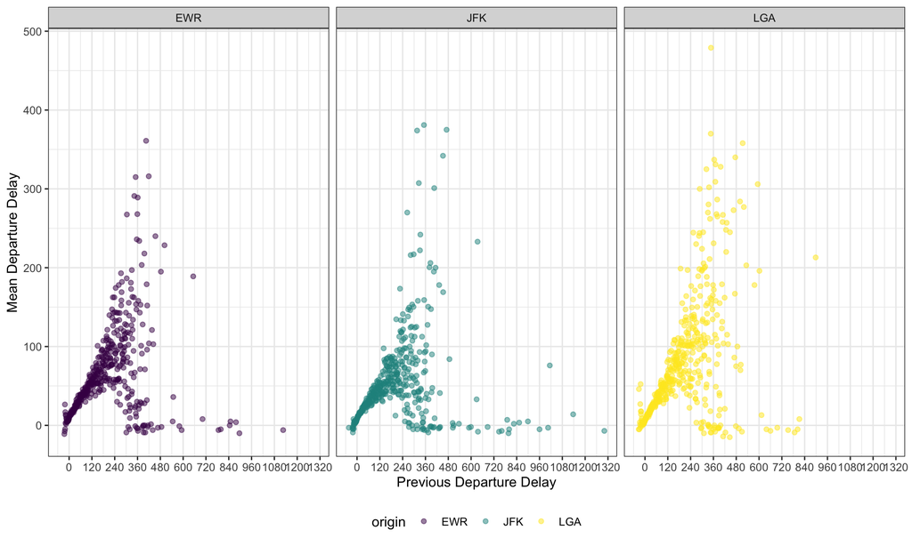

```r
# Your answer starts here
lagged_delays <- flights %>%
  arrange(origin, month, day, dep_time) %>%
  group_by(origin) %>%
  mutate(dep_delay_lag = lag(dep_delay)) %>%
  filter(!is.na(dep_delay), !is.na(dep_delay_lag))

lagged_delays %>%
  group_by(dep_delay_lag, origin) %>%
  summarise(dep_delay_mean = mean(dep_delay)) %>%
  ggplot(aes(y = dep_delay_mean, x = dep_delay_lag, color = origin)) +
  geom_point(alpha = 0.5) +
  scale_x_continuous(breaks = seq(0, 1500, by = 120)) +
  labs(y = "Mean Departure Delay", x = "Previous Departure Delay") +
  facet_wrap(.~origin)
```